# Risk Factor Analysis

## Outcome Variable

**Outcome Variable:** ever_sstunted

## Predictor Variables

**Intervention Variable:** sex

**Adjustment Set:**

unadjusted

## Stratifying Variables

The analysis was stratified on these variable(s):

- agecat
- studyid
- country

## Data Summary

| agecat | studyid | country | sex | ever_sstunted | n_cell | n |
| --- | --- | --- | --- | --- | --- | --- |
| 0-24 months | CMC-V-BCS-2002 | INDIA | Female | 0 | 80 | 373 |
| 0-24 months | CMC-V-BCS-2002 | INDIA | Female | 1 | 107 | 373 |
| 0-24 months | CMC-V-BCS-2002 | INDIA | Male | 0 | 56 | 373 |
| 0-24 months | CMC-V-BCS-2002 | INDIA | Male | 1 | 130 | 373 |
| 0-24 months | CMIN | BANGLADESH | Female | 0 | 60 | 277 |
| 0-24 months | CMIN | BANGLADESH | Female | 1 | 60 | 277 |
| 0-24 months | CMIN | BANGLADESH | Male | 0 | 79 | 277 |
| 0-24 months | CMIN | BANGLADESH | Male | 1 | 78 | 277 |
| 0-24 months | COHORTS | GUATEMALA | Female | 0 | 365 | 1368 |
| 0-24 months | COHORTS | GUATEMALA | Female | 1 | 279 | 1368 |
| 0-24 months | COHORTS | GUATEMALA | Male | 0 | 368 | 1368 |
| 0-24 months | COHORTS | GUATEMALA | Male | 1 | 356 | 1368 |
| 0-24 months | COHORTS | INDIA | Female | 0 | 3163 | 7417 |
| 0-24 months | COHORTS | INDIA | Female | 1 | 391 | 7417 |
| 0-24 months | COHORTS | INDIA | Male | 0 | 3308 | 7417 |
| 0-24 months | COHORTS | INDIA | Male | 1 | 555 | 7417 |
| 0-24 months | COHORTS | PHILIPPINES | Female | 0 | 972 | 3058 |
| 0-24 months | COHORTS | PHILIPPINES | Female | 1 | 465 | 3058 |
| 0-24 months | COHORTS | PHILIPPINES | Male | 0 | 997 | 3058 |
| 0-24 months | COHORTS | PHILIPPINES | Male | 1 | 624 | 3058 |
| 0-24 months | CONTENT | PERU | Female | 0 | 107 | 215 |
| 0-24 months | CONTENT | PERU | Female | 1 | 2 | 215 |
| 0-24 months | CONTENT | PERU | Male | 0 | 98 | 215 |
| 0-24 months | CONTENT | PERU | Male | 1 | 8 | 215 |
| 0-24 months | EE | PAKISTAN | Female | 0 | 76 | 379 |
| 0-24 months | EE | PAKISTAN | Female | 1 | 109 | 379 |
| 0-24 months | EE | PAKISTAN | Male | 0 | 75 | 379 |
| 0-24 months | EE | PAKISTAN | Male | 1 | 119 | 379 |
| 0-24 months | GMS-Nepal | NEPAL | Female | 0 | 253 | 698 |
| 0-24 months | GMS-Nepal | NEPAL | Female | 1 | 75 | 698 |

[output cut: 198 more lines]

The following strata were considered:

- agecat: 0-24 months, studyid: CMC-V-BCS-2002, country: INDIA
- agecat: 0-24 months, studyid: CMIN, country: BANGLADESH
- agecat: 0-24 months, studyid: COHORTS, country: GUATEMALA
- agecat: 0-24 months, studyid: COHORTS, country: INDIA
- agecat: 0-24 months, studyid: COHORTS, country: PHILIPPINES
- agecat: 0-24 months, studyid: CONTENT, country: PERU
- agecat: 0-24 months, studyid: EE, country: PAKISTAN
- agecat: 0-24 months, studyid: GMS-Nepal, country: NEPAL
- agecat: 0-24 months, studyid: Guatemala BSC, country: GUATEMALA
- agecat: 0-24 months, studyid: iLiNS-Zinc, country: BURKINA FASO
- agecat: 0-24 months, studyid: IRC, country: INDIA
- agecat: 0-24 months, studyid: Keneba, country: GAMBIA
- agecat: 0-24 months, studyid: LCNI-5, country: MALAWI
- agecat: 0-24 months, studyid: MAL-ED, country: BANGLADESH
- agecat: 0-24 months, studyid: MAL-ED, country: BRAZIL
- agecat: 0-24 months, studyid: MAL-ED, country: INDIA
- agecat: 0-24 months, studyid: MAL-ED, country: NEPAL
- agecat: 0-24 months, studyid: MAL-ED, country: PERU
- agecat: 0-24 months, studyid: MAL-ED, country: SOUTH AFRICA
- agecat: 0-24 months, studyid: MAL-ED, country: TANZANIA, UNITED REPUBLIC OF
- agecat: 0-24 months, studyid: NIH-Birth, country: BANGLADESH
- agecat: 0-24 months, studyid: NIH-Crypto, country: BANGLADESH
- agecat: 0-24 months, studyid: PROBIT, country: BELARUS
- agecat: 0-24 months, studyid: PROVIDE, country: BANGLADESH
- agecat: 0-24 months, studyid: ResPak, country: PAKISTAN
- agecat: 0-24 months, studyid: SAS-CompFeed, country: INDIA
- agecat: 0-24 months, studyid: SAS-FoodSuppl, country: INDIA
- agecat: 0-24 months, studyid: TanzaniaChild2, country: TANZANIA, UNITED REPUBLIC OF
- agecat: 0-24 months, studyid: ZVITAMBO, country: ZIMBABWE
- agecat: 0-6 months, studyid: CMC-V-BCS-2002, country: INDIA
- agecat: 0-6 months, studyid: CMIN, country: BANGLADESH
- agecat: 0-6 months, studyid: COHORTS, country: GUATEMALA
- agecat: 0-6 months, studyid: COHORTS, country: INDIA
- agecat: 0-6 months, studyid: COHORTS, country: PHILIPPINES
- agecat: 0-6 months, studyid: CONTENT, country: PERU
- agecat: 0-6 months, studyid: EE, country: PAKISTAN
- agecat: 0-6 months, studyid: GMS-Nepal, country: NEPAL
- agecat: 0-6 months, studyid: Guatemala BSC, country: GUATEMALA
- agecat: 0-6 months, studyid: IRC, country: INDIA
- agecat: 0-6 months, studyid: Keneba, country: GAMBIA
- agecat: 0-6 months, studyid: LCNI-5, country: MALAWI
- agecat: 0-6 months, studyid: MAL-ED, country: BANGLADESH
- agecat: 0-6 months, studyid: MAL-ED, country: BRAZIL
- agecat: 0-6 months, studyid: MAL-ED, country: INDIA
- agecat: 0-6 months, studyid: MAL-ED, country: NEPAL
- agecat: 0-6 months, studyid: MAL-ED, country: PERU
- agecat: 0-6 months, studyid: MAL-ED, country: SOUTH AFRICA
- agecat: 0-6 months, studyid: MAL-ED, country: TANZANIA, UNITED REPUBLIC OF
- agecat: 0-6 months, studyid: NIH-Birth, country: BANGLADESH
- agecat: 0-6 months, studyid: NIH-Crypto, country: BANGLADESH
- agecat: 0-6 months, studyid: PROBIT, country: BELARUS
- agecat: 0-6 months, studyid: PROVIDE, country: BANGLADESH
- agecat: 0-6 months, studyid: ResPak, country: PAKISTAN
- agecat: 0-6 months, studyid: SAS-CompFeed, country: INDIA
- agecat: 0-6 months, studyid: SAS-FoodSuppl, country: INDIA
- agecat: 0-6 months, studyid: TanzaniaChild2, country: TANZANIA, UNITED REPUBLIC OF
- agecat: 0-6 months, studyid: ZVITAMBO, country: ZIMBABWE

### Dropped Strata

Some strata were dropped due to rare outcomes:

- agecat: 0-24 months, studyid: CONTENT, country: PERU
- agecat: 0-6 months, studyid: CONTENT, country: PERU
- agecat: 0-6 months, studyid: LCNI-5, country: MALAWI
- agecat: 0-6 months, studyid: MAL-ED, country: NEPAL

## Methods Detail

We’re interested in the causal parameters $E[Y_a]$ for all values of $a \in \mathcal{A}$. These parameters represent the mean outcome if, possibly contrary to fact, we intervened to set all units to have $A=a$. Under the randomization and positivity assumptions, these are identified by the statistical parameters $\psi_a=E_W[E_{Y|A,W}(Y|A=a,W)]$. In addition, we’re interested in the mean of $Y$, $E[Y]$ under no intervention (the observed mean). We will estimate these parameters by using SuperLearner to fit the relevant likelihood factors – $E_{Y|A,W}(Y|A=a,W)$ and $p(A=a|W)$, and then updating our likelihood fit using a joint TMLE.

For unadjusted analyses ($W=\{\}$), initial likelihoods were estimated using Lrnr_glm to estimate the simple $E(Y|A)$ and Lrnr_mean to estimate $p(A)$. For adjusted analyses, a small library containing Lrnr_glmnet, Lrnr_xgboost, and Lrnr_mean was used.

Having estimated these parameters, we will then use the delta method to estimate relative risks and attributable risks relative to a prespecified baseline level of $A$.

# Results Detail

## Results Plots

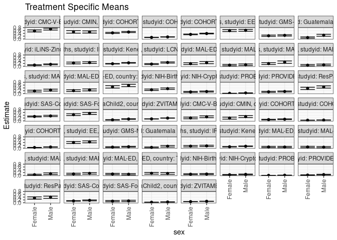

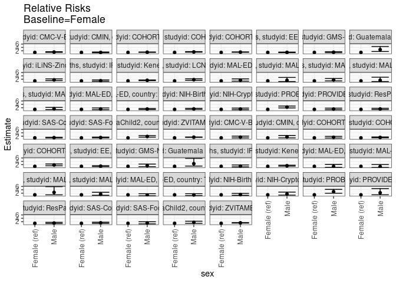

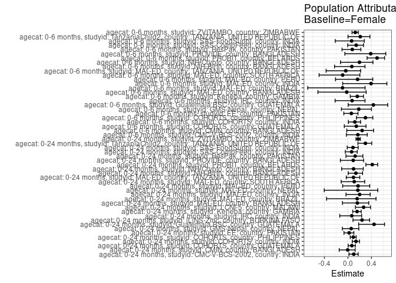

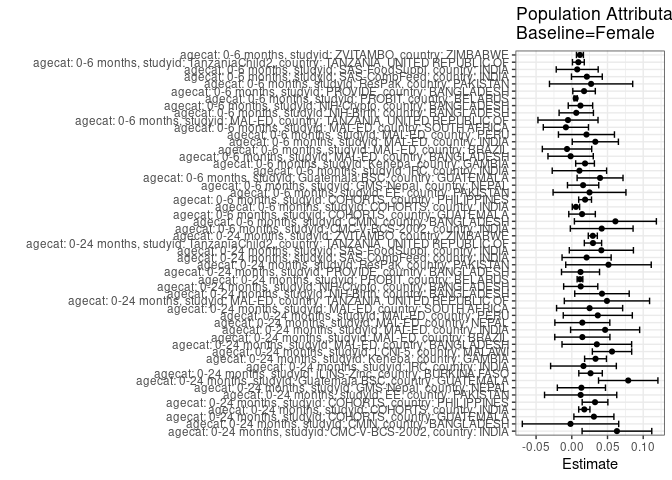

## Results Table

### Parameter: TSM

| agecat | studyid | country | intervention_level | baseline_level | estimate | ci_lower | ci_upper |
| --- | --- | --- | --- | --- | --- | --- | --- |
| 0-24 months | CMC-V-BCS-2002 | INDIA | Female | NA | 0.5721925 | 0.5011848 | 0.6432002 |
| 0-24 months | CMC-V-BCS-2002 | INDIA | Male | NA | 0.6989247 | 0.6329121 | 0.7649374 |
| 0-24 months | CMIN | BANGLADESH | Female | NA | 0.5000000 | 0.4103784 | 0.5896216 |
| 0-24 months | CMIN | BANGLADESH | Male | NA | 0.4968153 | 0.4184642 | 0.5751663 |
| 0-24 months | COHORTS | GUATEMALA | Female | NA | 0.4332298 | 0.3949450 | 0.4715146 |
| 0-24 months | COHORTS | GUATEMALA | Male | NA | 0.4917127 | 0.4552836 | 0.5281418 |
| 0-24 months | COHORTS | INDIA | Female | NA | 0.1100169 | 0.0997287 | 0.1203051 |
| 0-24 months | COHORTS | INDIA | Male | NA | 0.1436707 | 0.1326091 | 0.1547324 |
| 0-24 months | COHORTS | PHILIPPINES | Female | NA | 0.3235908 | 0.2993976 | 0.3477840 |
| 0-24 months | COHORTS | PHILIPPINES | Male | NA | 0.3849476 | 0.3612565 | 0.4086386 |
| 0-24 months | EE | PAKISTAN | Female | NA | 0.5891892 | 0.5182013 | 0.6601771 |
| 0-24 months | EE | PAKISTAN | Male | NA | 0.6134021 | 0.5447864 | 0.6820177 |
| 0-24 months | GMS-Nepal | NEPAL | Female | NA | 0.2286585 | 0.1831765 | 0.2741405 |
| 0-24 months | GMS-Nepal | NEPAL | Male | NA | 0.2540541 | 0.2096651 | 0.2984430 |
| 0-24 months | Guatemala BSC | GUATEMALA | Female | NA | 0.0987654 | 0.0527501 | 0.1447808 |
| 0-24 months | Guatemala BSC | GUATEMALA | Male | NA | 0.2614379 | 0.1916997 | 0.3311761 |
| 0-24 months | iLiNS-Zinc | BURKINA FASO | Female | NA | 0.0830769 | 0.0629294 | 0.1032244 |
| 0-24 months | iLiNS-Zinc | BURKINA FASO | Male | NA | 0.1353659 | 0.1044940 | 0.1662377 |
| 0-24 months | IRC | INDIA | Female | NA | 0.2324324 | 0.1714929 | 0.2933720 |
| 0-24 months | IRC | INDIA | Male | NA | 0.2622222 | 0.2046803 | 0.3197642 |
| 0-24 months | Keneba | GAMBIA | Female | NA | 0.1791045 | 0.1590656 | 0.1991433 |
| 0-24 months | Keneba | GAMBIA | Male | NA | 0.2433687 | 0.2217068 | 0.2650306 |
| 0-24 months | LCNI-5 | MALAWI | Female | NA | 0.1543943 | 0.1198588 | 0.1889298 |
| 0-24 months | LCNI-5 | MALAWI | Male | NA | 0.2673031 | 0.2249033 | 0.3097029 |
| 0-24 months | MAL-ED | BANGLADESH | Female | NA | 0.1838235 | 0.1186018 | 0.2490452 |
| 0-24 months | MAL-ED | BANGLADESH | Male | NA | 0.2558140 | 0.1803782 | 0.3312497 |
| 0-24 months | MAL-ED | BRAZIL | Female | NA | 0.0796460 | 0.0296193 | 0.1296728 |
| 0-24 months | MAL-ED | BRAZIL | Male | NA | 0.1083333 | 0.0526053 | 0.1640614 |
| 0-24 months | MAL-ED | INDIA | Female | NA | 0.1884058 | 0.1230338 | 0.2537778 |
| 0-24 months | MAL-ED | INDIA | Male | NA | 0.2920354 | 0.2080315 | 0.3760393 |

[output cut: 76 more lines]

### Parameter: E(Y)

| agecat | studyid | country | intervention_level | baseline_level | estimate | ci_lower | ci_upper |
| --- | --- | --- | --- | --- | --- | --- | --- |
| 0-24 months | CMC-V-BCS-2002 | INDIA | NA | NA | 0.6353887 | 0.5864772 | 0.6843003 |
| 0-24 months | CMIN | BANGLADESH | NA | NA | 0.4981949 | 0.4392073 | 0.5571825 |
| 0-24 months | COHORTS | GUATEMALA | NA | NA | 0.4641813 | 0.4377440 | 0.4906186 |
| 0-24 months | COHORTS | INDIA | NA | NA | 0.1275448 | 0.1199527 | 0.1351370 |
| 0-24 months | COHORTS | PHILIPPINES | NA | NA | 0.3561151 | 0.3391405 | 0.3730897 |
| 0-24 months | EE | PAKISTAN | NA | NA | 0.6015831 | 0.5522295 | 0.6509367 |
| 0-24 months | GMS-Nepal | NEPAL | NA | NA | 0.2421203 | 0.2103189 | 0.2739218 |
| 0-24 months | Guatemala BSC | GUATEMALA | NA | NA | 0.1777778 | 0.1354898 | 0.2200657 |
| 0-24 months | iLiNS-Zinc | BURKINA FASO | NA | NA | 0.1093415 | 0.0900773 | 0.1286057 |
| 0-24 months | IRC | INDIA | NA | NA | 0.2487805 | 0.2068840 | 0.2906770 |
| 0-24 months | Keneba | GAMBIA | NA | NA | 0.2123499 | 0.1975010 | 0.2271989 |
| 0-24 months | LCNI-5 | MALAWI | NA | NA | 0.2107143 | 0.1831192 | 0.2383093 |
| 0-24 months | MAL-ED | BANGLADESH | NA | NA | 0.2188679 | 0.1689910 | 0.2687448 |
| 0-24 months | MAL-ED | BRAZIL | NA | NA | 0.0944206 | 0.0567935 | 0.1320477 |
| 0-24 months | MAL-ED | INDIA | NA | NA | 0.2350598 | 0.1824967 | 0.2876229 |
| 0-24 months | MAL-ED | NEPAL | NA | NA | 0.0875000 | 0.0516764 | 0.1233236 |
| 0-24 months | MAL-ED | PERU | NA | NA | 0.2112211 | 0.1651858 | 0.2572564 |
| 0-24 months | MAL-ED | SOUTH AFRICA | NA | NA | 0.2324841 | 0.1856873 | 0.2792809 |
| 0-24 months | MAL-ED | TANZANIA, UNITED REPUBLIC OF | NA | NA | 0.5229008 | 0.4623051 | 0.5834965 |
| 0-24 months | NIH-Birth | BANGLADESH | NA | NA | 0.3116057 | 0.2753823 | 0.3478292 |
| 0-24 months | NIH-Crypto | BANGLADESH | NA | NA | 0.1306069 | 0.1066024 | 0.1546113 |
| 0-24 months | PROBIT | BELARUS | NA | NA | 0.0276380 | 0.0201988 | 0.0350773 |
| 0-24 months | PROVIDE | BANGLADESH | NA | NA | 0.1357143 | 0.1103250 | 0.1611036 |
| 0-24 months | ResPak | PAKISTAN | NA | NA | 0.4190141 | 0.3615294 | 0.4764987 |
| 0-24 months | SAS-CompFeed | INDIA | NA | NA | 0.3307241 | 0.3024794 | 0.3589688 |
| 0-24 months | SAS-FoodSuppl | INDIA | NA | NA | 0.4808612 | 0.4329065 | 0.5288160 |
| 0-24 months | TanzaniaChild2 | TANZANIA, UNITED REPUBLIC OF | NA | NA | 0.0997496 | 0.0877482 | 0.1117510 |
| 0-24 months | ZVITAMBO | ZIMBABWE | NA | NA | 0.1681114 | 0.1619329 | 0.1742900 |
| 0-6 months | CMC-V-BCS-2002 | INDIA | NA | NA | 0.2472826 | 0.2031431 | 0.2914222 |
| 0-6 months | CMIN | BANGLADESH | NA | NA | 0.2527076 | 0.2014394 | 0.3039758 |
| 0-6 months | COHORTS | GUATEMALA | NA | NA | 0.1007326 | 0.0828733 | 0.1185919 |
| 0-6 months | COHORTS | INDIA | NA | NA | 0.0491918 | 0.0441876 | 0.0541959 |
| 0-6 months | COHORTS | PHILIPPINES | NA | NA | 0.0624591 | 0.0538810 | 0.0710373 |
| 0-6 months | EE | PAKISTAN | NA | NA | 0.4248021 | 0.3749706 | 0.4746336 |
| 0-6 months | GMS-Nepal | NEPAL | NA | NA | 0.0859599 | 0.0651504 | 0.1067694 |
| 0-6 months | Guatemala BSC | GUATEMALA | NA | NA | 0.0915254 | 0.0585643 | 0.1244865 |
| 0-6 months | IRC | INDIA | NA | NA | 0.1512195 | 0.1164988 | 0.1859402 |
| 0-6 months | Keneba | GAMBIA | NA | NA | 0.1164300 | 0.1037657 | 0.1290943 |
| 0-6 months | MAL-ED | BANGLADESH | NA | NA | 0.0792453 | 0.0466613 | 0.1118293 |
| 0-6 months | MAL-ED | BRAZIL | NA | NA | 0.0729614 | 0.0394957 | 0.1064270 |
| 0-6 months | MAL-ED | INDIA | NA | NA | 0.0836653 | 0.0493429 | 0.1179878 |
| 0-6 months | MAL-ED | PERU | NA | NA | 0.1254125 | 0.0880603 | 0.1627648 |
| 0-6 months | MAL-ED | SOUTH AFRICA | NA | NA | 0.0923567 | 0.0602816 | 0.1244318 |
| 0-6 months | MAL-ED | TANZANIA, UNITED REPUBLIC OF | NA | NA | 0.1450382 | 0.1023171 | 0.1877593 |
| 0-6 months | NIH-Birth | BANGLADESH | NA | NA | 0.0937997 | 0.0709973 | 0.1166021 |
| 0-6 months | NIH-Crypto | BANGLADESH | NA | NA | 0.0620053 | 0.0448256 | 0.0791849 |
| 0-6 months | PROBIT | BELARUS | NA | NA | 0.0109519 | 0.0074064 | 0.0144975 |
| 0-6 months | PROVIDE | BANGLADESH | NA | NA | 0.0442857 | 0.0290345 | 0.0595370 |
| 0-6 months | ResPak | PAKISTAN | NA | NA | 0.3652482 | 0.3089505 | 0.4215460 |
| 0-6 months | SAS-CompFeed | INDIA | NA | NA | 0.1496732 | 0.1307571 | 0.1685893 |
| 0-6 months | SAS-FoodSuppl | INDIA | NA | NA | 0.1201923 | 0.0889059 | 0.1514788 |
| 0-6 months | TanzaniaChild2 | TANZANIA, UNITED REPUBLIC OF | NA | NA | 0.0438230 | 0.0356249 | 0.0520212 |
| 0-6 months | ZVITAMBO | ZIMBABWE | NA | NA | 0.0912001 | 0.0864407 | 0.0959595 |

### Parameter: RR

| agecat | studyid | country | intervention_level | baseline_level | estimate | ci_lower | ci_upper |
| --- | --- | --- | --- | --- | --- | --- | --- |
| 0-24 months | CMC-V-BCS-2002 | INDIA | Female | Female | 1.0000000 | 1.0000000 | 1.000000 |
| 0-24 months | CMC-V-BCS-2002 | INDIA | Male | Female | 1.2214853 | 1.0451039 | 1.427634 |
| 0-24 months | CMIN | BANGLADESH | Female | Female | 1.0000000 | 1.0000000 | 1.000000 |
| 0-24 months | CMIN | BANGLADESH | Male | Female | 0.9936306 | 0.7825985 | 1.261569 |
| 0-24 months | COHORTS | GUATEMALA | Female | Female | 1.0000000 | 1.0000000 | 1.000000 |
| 0-24 months | COHORTS | GUATEMALA | Male | Female | 1.1349928 | 1.0113730 | 1.273723 |
| 0-24 months | COHORTS | INDIA | Female | Female | 1.0000000 | 1.0000000 | 1.000000 |
| 0-24 months | COHORTS | INDIA | Male | Female | 1.3058971 | 1.1569166 | 1.474062 |
| 0-24 months | COHORTS | PHILIPPINES | Female | Female | 1.0000000 | 1.0000000 | 1.000000 |
| 0-24 months | COHORTS | PHILIPPINES | Male | Female | 1.1896121 | 1.0798157 | 1.310573 |
| 0-24 months | EE | PAKISTAN | Female | Female | 1.0000000 | 1.0000000 | 1.000000 |
| 0-24 months | EE | PAKISTAN | Male | Female | 1.0410952 | 0.8832628 | 1.227131 |
| 0-24 months | GMS-Nepal | NEPAL | Female | Female | 1.0000000 | 1.0000000 | 1.000000 |
| 0-24 months | GMS-Nepal | NEPAL | Male | Female | 1.1110631 | 0.8526276 | 1.447831 |
| 0-24 months | Guatemala BSC | GUATEMALA | Female | Female | 1.0000000 | 1.0000000 | 1.000000 |
| 0-24 months | Guatemala BSC | GUATEMALA | Male | Female | 2.6470588 | 1.5474149 | 4.528146 |
| 0-24 months | iLiNS-Zinc | BURKINA FASO | Female | Female | 1.0000000 | 1.0000000 | 1.000000 |
| 0-24 months | iLiNS-Zinc | BURKINA FASO | Male | Female | 1.6294038 | 1.2020731 | 2.208648 |
| 0-24 months | IRC | INDIA | Female | Female | 1.0000000 | 1.0000000 | 1.000000 |
| 0-24 months | IRC | INDIA | Male | Female | 1.1281654 | 0.8014734 | 1.588022 |
| 0-24 months | Keneba | GAMBIA | Female | Female | 1.0000000 | 1.0000000 | 1.000000 |
| 0-24 months | Keneba | GAMBIA | Male | Female | 1.3588086 | 1.1777881 | 1.567651 |
| 0-24 months | LCNI-5 | MALAWI | Female | Female | 1.0000000 | 1.0000000 | 1.000000 |
| 0-24 months | LCNI-5 | MALAWI | Male | Female | 1.7313016 | 1.3160788 | 2.277527 |
| 0-24 months | MAL-ED | BANGLADESH | Female | Female | 1.0000000 | 1.0000000 | 1.000000 |
| 0-24 months | MAL-ED | BANGLADESH | Male | Female | 1.3916279 | 0.8773260 | 2.207422 |
| 0-24 months | MAL-ED | BRAZIL | Female | Female | 1.0000000 | 1.0000000 | 1.000000 |
| 0-24 months | MAL-ED | BRAZIL | Male | Female | 1.3601852 | 0.6039536 | 3.063321 |
| 0-24 months | MAL-ED | INDIA | Female | Female | 1.0000000 | 1.0000000 | 1.000000 |
| 0-24 months | MAL-ED | INDIA | Male | Female | 1.5500340 | 0.9876502 | 2.432648 |

[output cut: 76 more lines]

### Parameter: PAR

| agecat | studyid | country | intervention_level | baseline_level | estimate | ci_lower | ci_upper |
| --- | --- | --- | --- | --- | --- | --- | --- |
| 0-24 months | CMC-V-BCS-2002 | INDIA | Female | NA | 0.0631962 | 0.0144231 | 0.1119694 |
| 0-24 months | CMIN | BANGLADESH | Female | NA | -0.0018051 | -0.0692766 | 0.0656665 |
| 0-24 months | COHORTS | GUATEMALA | Female | NA | 0.0309515 | 0.0029400 | 0.0589630 |
| 0-24 months | COHORTS | INDIA | Female | NA | 0.0175279 | 0.0096507 | 0.0254052 |
| 0-24 months | COHORTS | PHILIPPINES | Female | NA | 0.0325243 | 0.0145422 | 0.0505064 |
| 0-24 months | EE | PAKISTAN | Female | NA | 0.0123939 | -0.0381575 | 0.0629453 |
| 0-24 months | GMS-Nepal | NEPAL | Female | NA | 0.0134618 | -0.0202399 | 0.0471635 |
| 0-24 months | Guatemala BSC | GUATEMALA | Female | NA | 0.0790123 | 0.0374459 | 0.1205788 |
| 0-24 months | iLiNS-Zinc | BURKINA FASO | Female | NA | 0.0262646 | 0.0098180 | 0.0427111 |
| 0-24 months | IRC | INDIA | Female | NA | 0.0163481 | -0.0296696 | 0.0623657 |
| 0-24 months | Keneba | GAMBIA | Female | NA | 0.0332454 | 0.0179352 | 0.0485557 |
| 0-24 months | LCNI-5 | MALAWI | Female | NA | 0.0563200 | 0.0287764 | 0.0838635 |
| 0-24 months | MAL-ED | BANGLADESH | Female | NA | 0.0350444 | -0.0136930 | 0.0837818 |
| 0-24 months | MAL-ED | BRAZIL | Female | NA | 0.0147746 | -0.0238387 | 0.0533879 |
| 0-24 months | MAL-ED | INDIA | Female | NA | 0.0466540 | -0.0016910 | 0.0949989 |
| 0-24 months | MAL-ED | NEPAL | Female | NA | 0.0147727 | -0.0237034 | 0.0532488 |
| 0-24 months | MAL-ED | PERU | Female | NA | 0.0363959 | -0.0119507 | 0.0847426 |
| 0-24 months | MAL-ED | SOUTH AFRICA | Female | NA | 0.0249369 | -0.0213141 | 0.0711880 |
| 0-24 months | MAL-ED | TANZANIA, UNITED REPUBLIC OF | Female | NA | 0.0492166 | -0.0104616 | 0.1088947 |
| 0-24 months | NIH-Birth | BANGLADESH | Female | NA | 0.0422455 | 0.0041140 | 0.0803769 |
| 0-24 months | NIH-Crypto | BANGLADESH | Female | NA | 0.0124966 | -0.0113919 | 0.0363852 |
| 0-24 months | PROBIT | BELARUS | Female | NA | 0.0114497 | 0.0074589 | 0.0154404 |
| 0-24 months | PROVIDE | BANGLADESH | Female | NA | 0.0122203 | -0.0144090 | 0.0388496 |
| 0-24 months | ResPak | PAKISTAN | Female | NA | 0.0513670 | -0.0084906 | 0.1112246 |
| 0-24 months | SAS-CompFeed | INDIA | Female | NA | 0.0207241 | -0.0136409 | 0.0550890 |
| 0-24 months | SAS-FoodSuppl | INDIA | Female | NA | 0.0413994 | -0.0034864 | 0.0862851 |
| 0-24 months | TanzaniaChild2 | TANZANIA, UNITED REPUBLIC OF | Female | NA | 0.0296482 | 0.0175442 | 0.0417522 |
| 0-24 months | ZVITAMBO | ZIMBABWE | Female | NA | 0.0294135 | 0.0230809 | 0.0357461 |
| 0-6 months | CMC-V-BCS-2002 | INDIA | Female | NA | 0.0418772 | -0.0020526 | 0.0858070 |
| 0-6 months | CMIN | BANGLADESH | Female | NA | 0.0610409 | 0.0036536 | 0.1184283 |
| 0-6 months | COHORTS | GUATEMALA | Female | NA | 0.0143602 | -0.0042306 | 0.0329511 |
| 0-6 months | COHORTS | INDIA | Female | NA | 0.0058009 | 0.0006608 | 0.0109411 |
| 0-6 months | COHORTS | PHILIPPINES | Female | NA | 0.0186178 | 0.0096551 | 0.0275805 |
| 0-6 months | EE | PAKISTAN | Female | NA | 0.0248021 | -0.0262061 | 0.0758103 |
| 0-6 months | GMS-Nepal | NEPAL | Female | NA | 0.0158379 | -0.0060494 | 0.0377252 |
| 0-6 months | Guatemala BSC | GUATEMALA | Female | NA | 0.0395774 | 0.0074509 | 0.0717039 |
| 0-6 months | IRC | INDIA | Female | NA | 0.0106790 | -0.0274107 | 0.0487686 |
| 0-6 months | Keneba | GAMBIA | Female | NA | 0.0185397 | 0.0054469 | 0.0316325 |
| 0-6 months | MAL-ED | BANGLADESH | Female | NA | -0.0016371 | -0.0333552 | 0.0300811 |
| 0-6 months | MAL-ED | BRAZIL | Female | NA | -0.0066846 | -0.0412554 | 0.0278861 |
| 0-6 months | MAL-ED | INDIA | Female | NA | 0.0329407 | 0.0006299 | 0.0652515 |
| 0-6 months | MAL-ED | PERU | Female | NA | 0.0205174 | -0.0186893 | 0.0597242 |
| 0-6 months | MAL-ED | SOUTH AFRICA | Female | NA | -0.0082722 | -0.0399087 | 0.0233642 |
| 0-6 months | MAL-ED | TANZANIA, UNITED REPUBLIC OF | Female | NA | -0.0053378 | -0.0473917 | 0.0367162 |
| 0-6 months | NIH-Birth | BANGLADESH | Female | NA | 0.0062576 | -0.0177743 | 0.0302895 |
| 0-6 months | NIH-Crypto | BANGLADESH | Female | NA | 0.0121365 | -0.0049695 | 0.0292425 |
| 0-6 months | PROBIT | BELARUS | Female | NA | 0.0054318 | 0.0031488 | 0.0077148 |
| 0-6 months | PROVIDE | BANGLADESH | Female | NA | 0.0171773 | 0.0014192 | 0.0329354 |
| 0-6 months | ResPak | PAKISTAN | Female | NA | 0.0270129 | -0.0312488 | 0.0852747 |
| 0-6 months | SAS-CompFeed | INDIA | Female | NA | 0.0211018 | -0.0004627 | 0.0426662 |
| 0-6 months | SAS-FoodSuppl | INDIA | Female | NA | 0.0075797 | -0.0217831 | 0.0369425 |
| 0-6 months | TanzaniaChild2 | TANZANIA, UNITED REPUBLIC OF | Female | NA | 0.0091947 | 0.0009195 | 0.0174698 |
| 0-6 months | ZVITAMBO | ZIMBABWE | Female | NA | 0.0113934 | 0.0065124 | 0.0162744 |

### Parameter: PAF

| agecat | studyid | country | intervention_level | baseline_level | estimate | ci_lower | ci_upper |
| --- | --- | --- | --- | --- | --- | --- | --- |
| 0-24 months | CMC-V-BCS-2002 | INDIA | Female | NA | 0.0994607 | 0.0184481 | 0.1737870 |
| 0-24 months | CMIN | BANGLADESH | Female | NA | -0.0036232 | -0.1486190 | 0.1230691 |
| 0-24 months | COHORTS | GUATEMALA | Female | NA | 0.0666797 | 0.0042614 | 0.1251853 |
| 0-24 months | COHORTS | INDIA | Female | NA | 0.1374258 | 0.0738370 | 0.1966486 |
| 0-24 months | COHORTS | PHILIPPINES | Female | NA | 0.0913308 | 0.0394053 | 0.1404495 |
| 0-24 months | EE | PAKISTAN | Female | NA | 0.0206022 | -0.0671749 | 0.1011594 |
| 0-24 months | GMS-Nepal | NEPAL | Female | NA | 0.0555997 | -0.0942874 | 0.1849563 |
| 0-24 months | Guatemala BSC | GUATEMALA | Female | NA | 0.4444444 | 0.1820801 | 0.6226501 |
| 0-24 months | iLiNS-Zinc | BURKINA FASO | Female | NA | 0.2402069 | 0.0861335 | 0.3683042 |
| 0-24 months | IRC | INDIA | Female | NA | 0.0657128 | -0.1386877 | 0.2334223 |
| 0-24 months | Keneba | GAMBIA | Female | NA | 0.1565597 | 0.0817841 | 0.2252459 |
| 0-24 months | LCNI-5 | MALAWI | Female | NA | 0.2672813 | 0.1276227 | 0.3845820 |
| 0-24 months | MAL-ED | BANGLADESH | Female | NA | 0.1601166 | -0.0928059 | 0.3545019 |
| 0-24 months | MAL-ED | BRAZIL | Female | NA | 0.1564763 | -0.3633938 | 0.4781168 |
| 0-24 months | MAL-ED | INDIA | Female | NA | 0.1984770 | -0.0328363 | 0.3779856 |
| 0-24 months | MAL-ED | NEPAL | Female | NA | 0.1688312 | -0.4029836 | 0.5075911 |
| 0-24 months | MAL-ED | PERU | Female | NA | 0.1723121 | -0.0890912 | 0.3709734 |
| 0-24 months | MAL-ED | SOUTH AFRICA | Female | NA | 0.1072629 | -0.1149164 | 0.2851665 |
| 0-24 months | MAL-ED | TANZANIA, UNITED REPUBLIC OF | Female | NA | 0.0941222 | -0.0280895 | 0.2018062 |
| 0-24 months | NIH-Birth | BANGLADESH | Female | NA | 0.1355734 | 0.0043719 | 0.2494855 |
| 0-24 months | NIH-Crypto | BANGLADESH | Female | NA | 0.0956812 | -0.1062779 | 0.2607712 |
| 0-24 months | PROBIT | BELARUS | Female | NA | 0.4142721 | 0.3058921 | 0.5057292 |
| 0-24 months | PROVIDE | BANGLADESH | Female | NA | 0.0900444 | -0.1282918 | 0.2661302 |
| 0-24 months | ResPak | PAKISTAN | Female | NA | 0.1225902 | -0.0328593 | 0.2546439 |
| 0-24 months | SAS-CompFeed | INDIA | Female | NA | 0.0626627 | -0.0446081 | 0.1589179 |
| 0-24 months | SAS-FoodSuppl | INDIA | Female | NA | 0.0860942 | -0.0124865 | 0.1750765 |
| 0-24 months | TanzaniaChild2 | TANZANIA, UNITED REPUBLIC OF | Female | NA | 0.2972266 | 0.1701477 | 0.4048454 |
| 0-24 months | ZVITAMBO | ZIMBABWE | Female | NA | 0.1749645 | 0.1368070 | 0.2114353 |
| 0-6 months | CMC-V-BCS-2002 | INDIA | Female | NA | 0.1693496 | -0.0272770 | 0.3283407 |
| 0-6 months | CMIN | BANGLADESH | Female | NA | 0.2415476 | -0.0197142 | 0.4358713 |
| 0-6 months | COHORTS | GUATEMALA | Female | NA | 0.1425580 | -0.0616268 | 0.3074716 |
| 0-6 months | COHORTS | INDIA | Female | NA | 0.1179252 | 0.0076991 | 0.2159072 |
| 0-6 months | COHORTS | PHILIPPINES | Female | NA | 0.2980796 | 0.1454557 | 0.4234444 |
| 0-6 months | EE | PAKISTAN | Female | NA | 0.0583851 | -0.0697689 | 0.1711868 |
| 0-6 months | GMS-Nepal | NEPAL | Female | NA | 0.1842480 | -0.1100510 | 0.4005218 |
| 0-6 months | Guatemala BSC | GUATEMALA | Female | NA | 0.4324194 | 0.0044090 | 0.6764257 |
| 0-6 months | IRC | INDIA | Female | NA | 0.0706190 | -0.2182434 | 0.2909881 |
| 0-6 months | Keneba | GAMBIA | Female | NA | 0.1592349 | 0.0401075 | 0.2635780 |
| 0-6 months | MAL-ED | BANGLADESH | Female | NA | -0.0206583 | -0.5106301 | 0.3103915 |
| 0-6 months | MAL-ED | BRAZIL | Female | NA | -0.0916189 | -0.6825342 | 0.2917636 |
| 0-6 months | MAL-ED | INDIA | Female | NA | 0.3937198 | -0.0886486 | 0.6623560 |
| 0-6 months | MAL-ED | PERU | Female | NA | 0.1635996 | -0.2112544 | 0.4224453 |
| 0-6 months | MAL-ED | SOUTH AFRICA | Female | NA | -0.0895684 | -0.4905703 | 0.2035536 |
| 0-6 months | MAL-ED | TANZANIA, UNITED REPUBLIC OF | Female | NA | -0.0368025 | -0.3711828 | 0.2160349 |
| 0-6 months | NIH-Birth | BANGLADESH | Female | NA | 0.0667123 | -0.2275646 | 0.2904439 |
| 0-6 months | NIH-Crypto | BANGLADESH | Female | NA | 0.1957335 | -0.1266196 | 0.4258536 |
| 0-6 months | PROBIT | BELARUS | Female | NA | 0.4959685 | 0.3260762 | 0.6230319 |
| 0-6 months | PROVIDE | BANGLADESH | Female | NA | 0.3878741 | -0.0517628 | 0.6437427 |
| 0-6 months | ResPak | PAKISTAN | Female | NA | 0.0739577 | -0.1001490 | 0.2205108 |
| 0-6 months | SAS-CompFeed | INDIA | Female | NA | 0.1409857 | -0.0038641 | 0.2649347 |
| 0-6 months | SAS-FoodSuppl | INDIA | Female | NA | 0.0630631 | -0.2155102 | 0.2777923 |
| 0-6 months | TanzaniaChild2 | TANZANIA, UNITED REPUBLIC OF | Female | NA | 0.2098134 | 0.0013534 | 0.3747589 |
| 0-6 months | ZVITAMBO | ZIMBABWE | Female | NA | 0.1249276 | 0.0700863 | 0.1765346 |